# Risk Factor Analysis

## Outcome Variable

**Outcome Variable:** whz

## Predictor Variables

**Intervention Variable:** gagebrth

**Adjustment Set:**

- arm
- sex
- W_mage
- meducyrs
- feducyrs
- hhwealth_quart
- brthmon
- W_parity
- impsan
- delta_W_mage
- delta_meducyrs
- delta_feducyrs
- delta_hhwealth_quart
- delta_brthmon
- delta_W_parity
- delta_impsan

## Stratifying Variables

The analysis was stratified on these variable(s):

- agecat
- studyid
- country

## Data Summary

| agecat | studyid | country | gagebrth | n_cell | n | outcome_variable |
| --- | --- | --- | --- | --- | --- | --- |
| Birth | CMC-V-BCS-2002 | INDIA | Full or late term | 53 | 86 | whz |
| Birth | CMC-V-BCS-2002 | INDIA | Preterm | 11 | 86 | whz |
| Birth | CMC-V-BCS-2002 | INDIA | Early term | 22 | 86 | whz |
| Birth | COHORTS | GUATEMALA | Full or late term | 323 | 572 | whz |
| Birth | COHORTS | GUATEMALA | Preterm | 78 | 572 | whz |
| Birth | COHORTS | GUATEMALA | Early term | 171 | 572 | whz |
| Birth | COHORTS | INDIA | Full or late term | 553 | 1229 | whz |
| Birth | COHORTS | INDIA | Preterm | 259 | 1229 | whz |
| Birth | COHORTS | INDIA | Early term | 417 | 1229 | whz |
| Birth | COHORTS | PHILIPPINES | Full or late term | 1135 | 2874 | whz |
| Birth | COHORTS | PHILIPPINES | Preterm | 579 | 2874 | whz |
| Birth | COHORTS | PHILIPPINES | Early term | 1160 | 2874 | whz |
| Birth | IRC | INDIA | Full or late term | 213 | 328 | whz |
| Birth | IRC | INDIA | Preterm | 32 | 328 | whz |
| Birth | IRC | INDIA | Early term | 83 | 328 | whz |
| Birth | JiVitA-3 | BANGLADESH | Full or late term | 9668 | 17161 | whz |
| Birth | JiVitA-3 | BANGLADESH | Preterm | 2755 | 17161 | whz |
| Birth | JiVitA-3 | BANGLADESH | Early term | 4738 | 17161 | whz |
| Birth | Keneba | GAMBIA | Full or late term | 709 | 1439 | whz |
| Birth | Keneba | GAMBIA | Preterm | 206 | 1439 | whz |
| Birth | Keneba | GAMBIA | Early term | 524 | 1439 | whz |
| Birth | NIH-Crypto | BANGLADESH | Full or late term | 160 | 707 | whz |
| Birth | NIH-Crypto | BANGLADESH | Preterm | 240 | 707 | whz |
| Birth | NIH-Crypto | BANGLADESH | Early term | 307 | 707 | whz |
| Birth | PROBIT | BELARUS | Full or late term | 7065 | 13817 | whz |
| Birth | PROBIT | BELARUS | Preterm | 467 | 13817 | whz |
| Birth | PROBIT | BELARUS | Early term | 6285 | 13817 | whz |
| 6 months | CMC-V-BCS-2002 | INDIA | Full or late term | 212 | 346 | whz |
| 6 months | CMC-V-BCS-2002 | INDIA | Preterm | 51 | 346 | whz |
| 6 months | CMC-V-BCS-2002 | INDIA | Early term | 83 | 346 | whz |

[output cut: 57 more lines]

The following strata were considered:

- agecat: 24 months, studyid: CMC-V-BCS-2002, country: INDIA
- agecat: 24 months, studyid: COHORTS, country: GUATEMALA
- agecat: 24 months, studyid: COHORTS, country: INDIA
- agecat: 24 months, studyid: COHORTS, country: PHILIPPINES
- agecat: 24 months, studyid: IRC, country: INDIA
- agecat: 24 months, studyid: JiVitA-3, country: BANGLADESH
- agecat: 24 months, studyid: Keneba, country: GAMBIA
- agecat: 24 months, studyid: NIH-Crypto, country: BANGLADESH
- agecat: 24 months, studyid: PROBIT, country: BELARUS
- agecat: 24 months, studyid: TanzaniaChild2, country: TANZANIA, UNITED REPUBLIC OF
- agecat: 6 months, studyid: CMC-V-BCS-2002, country: INDIA
- agecat: 6 months, studyid: COHORTS, country: GUATEMALA
- agecat: 6 months, studyid: COHORTS, country: INDIA
- agecat: 6 months, studyid: COHORTS, country: PHILIPPINES
- agecat: 6 months, studyid: IRC, country: INDIA
- agecat: 6 months, studyid: JiVitA-3, country: BANGLADESH
- agecat: 6 months, studyid: Keneba, country: GAMBIA
- agecat: 6 months, studyid: NIH-Crypto, country: BANGLADESH
- agecat: 6 months, studyid: PROBIT, country: BELARUS
- agecat: 6 months, studyid: TanzaniaChild2, country: TANZANIA, UNITED REPUBLIC OF
- agecat: Birth, studyid: CMC-V-BCS-2002, country: INDIA
- agecat: Birth, studyid: COHORTS, country: GUATEMALA
- agecat: Birth, studyid: COHORTS, country: INDIA
- agecat: Birth, studyid: COHORTS, country: PHILIPPINES
- agecat: Birth, studyid: IRC, country: INDIA
- agecat: Birth, studyid: JiVitA-3, country: BANGLADESH
- agecat: Birth, studyid: Keneba, country: GAMBIA
- agecat: Birth, studyid: NIH-Crypto, country: BANGLADESH
- agecat: Birth, studyid: PROBIT, country: BELARUS

### Dropped Strata

Some strata were dropped due to rare outcomes:

- agecat: 24 months, studyid: TanzaniaChild2, country: TANZANIA, UNITED REPUBLIC OF

## Methods Detail

We’re interested in the causal parameters $E[Y_a]$ for all values of $a \in \mathcal{A}$. These parameters represent the mean outcome if, possibly contrary to fact, we intervened to set all units to have $A=a$. Under the randomization and positivity assumptions, these are identified by the statistical parameters $\psi_a=E_W[E_{Y|A,W}(Y|A=a,W)]$. In addition, we’re interested in the mean of $Y$, $E[Y]$ under no intervention (the observed mean). We will estimate these parameters by using SuperLearner to fit the relevant likelihood factors – $E_{Y|A,W}(Y|A=a,W)$ and $p(A=a|W)$, and then updating our likelihood fit using a joint TMLE.

For unadjusted analyses ($W=\{\}$), initial likelihoods were estimated using Lrnr_glm to estimate the simple $E(Y|A)$ and Lrnr_mean to estimate $p(A)$. For adjusted analyses, a small library containing Lrnr_glmnet, Lrnr_xgboost, and Lrnr_mean was used.

Having estimated these parameters, we will then use the delta method to estimate relative risks and attributable risks relative to a prespecified baseline level of $A$.

# Results Detail

## Results Plots

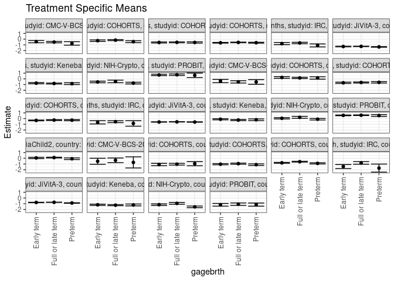

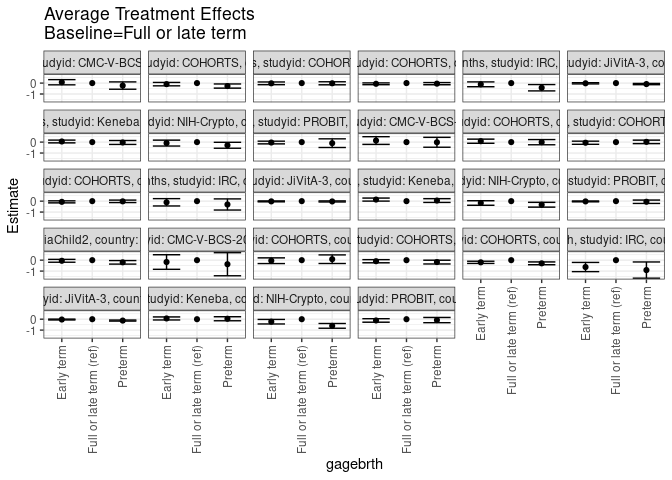

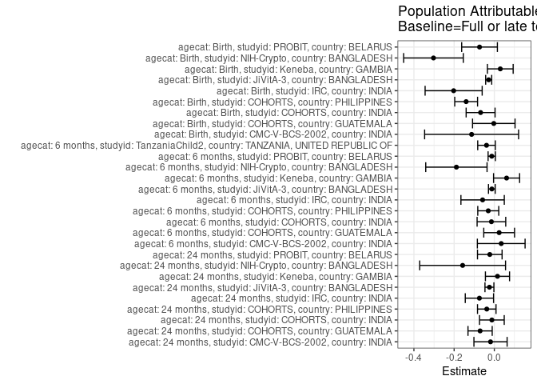

## Results Table

### Parameter: TSM

| agecat | studyid | country | intervention_level | baseline_level | estimate | ci_lower | ci_upper |
| --- | --- | --- | --- | --- | --- | --- | --- |
| Birth | CMC-V-BCS-2002 | INDIA | Full or late term | NA | -0.3517998 | -0.7564272 | 0.0528277 |
| Birth | CMC-V-BCS-2002 | INDIA | Preterm | NA | -0.7222143 | -1.6968601 | 0.2524314 |
| Birth | CMC-V-BCS-2002 | INDIA | Early term | NA | -0.5217331 | -1.0492399 | 0.0057736 |
| Birth | COHORTS | GUATEMALA | Full or late term | NA | -1.0331319 | -1.1941742 | -0.8720896 |
| Birth | COHORTS | GUATEMALA | Preterm | NA | -0.9438152 | -1.3043620 | -0.5832685 |
| Birth | COHORTS | GUATEMALA | Early term | NA | -1.0838858 | -1.2906972 | -0.8770744 |
| Birth | COHORTS | INDIA | Full or late term | NA | -0.9415267 | -1.0415034 | -0.8415501 |
| Birth | COHORTS | INDIA | Preterm | NA | -1.1150680 | -1.2552684 | -0.9748677 |
| Birth | COHORTS | INDIA | Early term | NA | -1.0356914 | -1.1405582 | -0.9308247 |
| Birth | COHORTS | PHILIPPINES | Full or late term | NA | -0.6015938 | -0.6739650 | -0.5292226 |
| Birth | COHORTS | PHILIPPINES | Preterm | NA | -0.8908850 | -0.9968939 | -0.7848760 |
| Birth | COHORTS | PHILIPPINES | Early term | NA | -0.7989934 | -0.8713963 | -0.7265905 |
| Birth | IRC | INDIA | Full or late term | NA | -0.8111034 | -1.0413111 | -0.5808957 |
| Birth | IRC | INDIA | Preterm | NA | -1.7178715 | -2.4195046 | -1.0162383 |
| Birth | IRC | INDIA | Early term | NA | -1.4409366 | -1.7927136 | -1.0891595 |
| Birth | JiVitA-3 | BANGLADESH | Full or late term | NA | -0.7514159 | -0.7764344 | -0.7263974 |
| Birth | JiVitA-3 | BANGLADESH | Preterm | NA | -0.8775321 | -0.9203827 | -0.8346815 |
| Birth | JiVitA-3 | BANGLADESH | Early term | NA | -0.7801179 | -0.8122928 | -0.7479429 |
| Birth | Keneba | GAMBIA | Full or late term | NA | -1.2592152 | -1.3505868 | -1.1678437 |
| Birth | Keneba | GAMBIA | Preterm | NA | -1.2170091 | -1.3769642 | -1.0570541 |
| Birth | Keneba | GAMBIA | Early term | NA | -1.1903752 | -1.2946749 | -1.0860756 |
| Birth | NIH-Crypto | BANGLADESH | Full or late term | NA | -0.9414663 | -1.1034580 | -0.7794746 |
| Birth | NIH-Crypto | BANGLADESH | Preterm | NA | -1.5503876 | -1.6951457 | -1.4056296 |
| Birth | NIH-Crypto | BANGLADESH | Early term | NA | -1.1687196 | -1.2986987 | -1.0387404 |
| Birth | PROBIT | BELARUS | Full or late term | NA | -1.0755834 | -1.2871878 | -0.8639790 |
| Birth | PROBIT | BELARUS | Preterm | NA | -1.1550207 | -1.4286857 | -0.8813557 |
| Birth | PROBIT | BELARUS | Early term | NA | -1.1900304 | -1.4245864 | -0.9554744 |
| 6 months | CMC-V-BCS-2002 | INDIA | Full or late term | NA | -0.5252365 | -0.7280502 | -0.3224227 |
| 6 months | CMC-V-BCS-2002 | INDIA | Preterm | NA | -0.5418197 | -0.9514618 | -0.1321776 |
| 6 months | CMC-V-BCS-2002 | INDIA | Early term | NA | -0.3820382 | -0.6737225 | -0.0903539 |

[output cut: 54 more lines]

### Parameter: E(Y)

| agecat | studyid | country | intervention_level | baseline_level | estimate | ci_lower | ci_upper |
| --- | --- | --- | --- | --- | --- | --- | --- |
| Birth | CMC-V-BCS-2002 | INDIA | NA | NA | -0.4648256 | -0.7643210 | -0.1653302 |
| Birth | COHORTS | GUATEMALA | NA | NA | -1.0358042 | -1.1559527 | -0.9156557 |
| Birth | COHORTS | INDIA | NA | NA | -1.0098535 | -1.0741510 | -0.9455561 |
| Birth | COHORTS | PHILIPPINES | NA | NA | -0.7417745 | -0.7882773 | -0.6952718 |
| Birth | IRC | INDIA | NA | NA | -1.0135366 | -1.2024730 | -0.8246002 |
| Birth | JiVitA-3 | BANGLADESH | NA | NA | -0.7794837 | -0.7988174 | -0.7601500 |
| Birth | Keneba | GAMBIA | NA | NA | -1.2295969 | -1.2924879 | -1.1667060 |
| Birth | NIH-Crypto | BANGLADESH | NA | NA | -1.2441513 | -1.3281130 | -1.1601897 |
| Birth | PROBIT | BELARUS | NA | NA | -1.1491782 | -1.3593933 | -0.9389630 |
| 6 months | CMC-V-BCS-2002 | INDIA | NA | NA | -0.4909778 | -0.6451612 | -0.3367945 |
| 6 months | COHORTS | GUATEMALA | NA | NA | 0.1864566 | 0.1024304 | 0.2704827 |
| 6 months | COHORTS | INDIA | NA | NA | -0.6460976 | -0.7081436 | -0.5840516 |
| 6 months | COHORTS | PHILIPPINES | NA | NA | -0.2920968 | -0.3336448 | -0.2505489 |
| 6 months | IRC | INDIA | NA | NA | -0.5999270 | -0.7403711 | -0.4594828 |
| 6 months | JiVitA-3 | BANGLADESH | NA | NA | -0.5906060 | -0.6106295 | -0.5705826 |
| 6 months | Keneba | GAMBIA | NA | NA | -0.1978013 | -0.2594875 | -0.1361150 |
| 6 months | NIH-Crypto | BANGLADESH | NA | NA | 0.0297622 | -0.0491685 | 0.1086930 |
| 6 months | PROBIT | BELARUS | NA | NA | 0.5741099 | 0.5141290 | 0.6340908 |
| 6 months | TanzaniaChild2 | TANZANIA, UNITED REPUBLIC OF | NA | NA | 0.0815655 | 0.0271217 | 0.1360092 |
| 24 months | CMC-V-BCS-2002 | INDIA | NA | NA | -0.5369143 | -0.6415957 | -0.4322329 |
| 24 months | COHORTS | GUATEMALA | NA | NA | -0.2397001 | -0.3082360 | -0.1711643 |
| 24 months | COHORTS | INDIA | NA | NA | -0.5717874 | -0.6260792 | -0.5174955 |
| 24 months | COHORTS | PHILIPPINES | NA | NA | -0.6079283 | -0.6449298 | -0.5709269 |
| 24 months | IRC | INDIA | NA | NA | -0.7414957 | -0.8350522 | -0.6479392 |
| 24 months | JiVitA-3 | BANGLADESH | NA | NA | -1.2935654 | -1.3174540 | -1.2696768 |
| 24 months | Keneba | GAMBIA | NA | NA | -0.7953404 | -0.8531640 | -0.7375168 |
| 24 months | NIH-Crypto | BANGLADESH | NA | NA | -0.6103502 | -0.7050157 | -0.5156847 |
| 24 months | PROBIT | BELARUS | NA | NA | 0.6981406 | 0.5843775 | 0.8119038 |

### Parameter: ATE

| agecat | studyid | country | intervention_level | baseline_level | estimate | ci_lower | ci_upper |
| --- | --- | --- | --- | --- | --- | --- | --- |
| Birth | CMC-V-BCS-2002 | INDIA | Full or late term | Full or late term | 0.0000000 | 0.0000000 | 0.0000000 |
| Birth | CMC-V-BCS-2002 | INDIA | Preterm | Full or late term | -0.3704146 | -1.4275558 | 0.6867267 |
| Birth | CMC-V-BCS-2002 | INDIA | Early term | Full or late term | -0.1699334 | -0.8371461 | 0.4972794 |
| Birth | COHORTS | GUATEMALA | Full or late term | Full or late term | 0.0000000 | 0.0000000 | 0.0000000 |
| Birth | COHORTS | GUATEMALA | Preterm | Full or late term | 0.0893167 | -0.3053979 | 0.4840313 |
| Birth | COHORTS | GUATEMALA | Early term | Full or late term | -0.0507539 | -0.3124222 | 0.2109144 |
| Birth | COHORTS | INDIA | Full or late term | Full or late term | 0.0000000 | 0.0000000 | 0.0000000 |
| Birth | COHORTS | INDIA | Preterm | Full or late term | -0.1735413 | -0.3455813 | -0.0015013 |
| Birth | COHORTS | INDIA | Early term | Full or late term | -0.0941647 | -0.2394524 | 0.0511231 |
| Birth | COHORTS | PHILIPPINES | Full or late term | Full or late term | 0.0000000 | 0.0000000 | 0.0000000 |
| Birth | COHORTS | PHILIPPINES | Preterm | Full or late term | -0.2892912 | -0.4172289 | -0.1613535 |
| Birth | COHORTS | PHILIPPINES | Early term | Full or late term | -0.1973996 | -0.2993919 | -0.0954074 |
| Birth | IRC | INDIA | Full or late term | Full or late term | 0.0000000 | 0.0000000 | 0.0000000 |
| Birth | IRC | INDIA | Preterm | Full or late term | -0.9067681 | -1.6473904 | -0.1661458 |
| Birth | IRC | INDIA | Early term | Full or late term | -0.6298332 | -1.0509299 | -0.2087365 |
| Birth | JiVitA-3 | BANGLADESH | Full or late term | Full or late term | 0.0000000 | 0.0000000 | 0.0000000 |
| Birth | JiVitA-3 | BANGLADESH | Preterm | Full or late term | -0.1261162 | -0.1749899 | -0.0772425 |
| Birth | JiVitA-3 | BANGLADESH | Early term | Full or late term | -0.0287019 | -0.0669397 | 0.0095359 |
| Birth | Keneba | GAMBIA | Full or late term | Full or late term | 0.0000000 | 0.0000000 | 0.0000000 |
| Birth | Keneba | GAMBIA | Preterm | Full or late term | 0.0422061 | -0.1414338 | 0.2258460 |
| Birth | Keneba | GAMBIA | Early term | Full or late term | 0.0688400 | -0.0695961 | 0.2072760 |
| Birth | NIH-Crypto | BANGLADESH | Full or late term | Full or late term | 0.0000000 | 0.0000000 | 0.0000000 |
| Birth | NIH-Crypto | BANGLADESH | Preterm | Full or late term | -0.6089213 | -0.8259546 | -0.3918881 |
| Birth | NIH-Crypto | BANGLADESH | Early term | Full or late term | -0.2272532 | -0.4351287 | -0.0193777 |
| Birth | PROBIT | BELARUS | Full or late term | Full or late term | 0.0000000 | 0.0000000 | 0.0000000 |
| Birth | PROBIT | BELARUS | Preterm | Full or late term | -0.0794373 | -0.3185449 | 0.1596702 |
| Birth | PROBIT | BELARUS | Early term | Full or late term | -0.1144470 | -0.2743955 | 0.0455014 |
| 6 months | CMC-V-BCS-2002 | INDIA | Full or late term | Full or late term | 0.0000000 | 0.0000000 | 0.0000000 |
| 6 months | CMC-V-BCS-2002 | INDIA | Preterm | Full or late term | -0.0165832 | -0.4699423 | 0.4367758 |
| 6 months | CMC-V-BCS-2002 | INDIA | Early term | Full or late term | 0.1431983 | -0.2099034 | 0.4962999 |

[output cut: 54 more lines]

### Parameter: PAR

| agecat | studyid | country | intervention_level | baseline_level | estimate | ci_lower | ci_upper |
| --- | --- | --- | --- | --- | --- | --- | --- |
| Birth | CMC-V-BCS-2002 | INDIA | Full or late term | NA | -0.1130258 | -0.3467013 | 0.1206497 |
| Birth | COHORTS | GUATEMALA | Full or late term | NA | -0.0026723 | -0.1083646 | 0.1030200 |
| Birth | COHORTS | INDIA | Full or late term | NA | -0.0683268 | -0.1402562 | 0.0036026 |
| Birth | COHORTS | PHILIPPINES | Full or late term | NA | -0.1401807 | -0.1969337 | -0.0834278 |
| Birth | IRC | INDIA | Full or late term | NA | -0.2024332 | -0.3443520 | -0.0605144 |
| Birth | JiVitA-3 | BANGLADESH | Full or late term | NA | -0.0280678 | -0.0430993 | -0.0130363 |
| Birth | Keneba | GAMBIA | Full or late term | NA | 0.0296183 | -0.0344282 | 0.0936648 |
| Birth | NIH-Crypto | BANGLADESH | Full or late term | NA | -0.3026850 | -0.4510452 | -0.1543249 |
| Birth | PROBIT | BELARUS | Full or late term | NA | -0.0735948 | -0.1624013 | 0.0152117 |
| 6 months | CMC-V-BCS-2002 | INDIA | Full or late term | NA | 0.0342586 | -0.0844596 | 0.1529769 |
| 6 months | COHORTS | GUATEMALA | Full or late term | NA | 0.0239446 | -0.0525725 | 0.1004616 |
| 6 months | COHORTS | INDIA | Full or late term | NA | -0.0144948 | -0.0857068 | 0.0567172 |
| 6 months | COHORTS | PHILIPPINES | Full or late term | NA | -0.0302170 | -0.0823608 | 0.0219268 |
| 6 months | IRC | INDIA | Full or late term | NA | -0.0583237 | -0.1661623 | 0.0495150 |
| 6 months | JiVitA-3 | BANGLADESH | Full or late term | NA | -0.0124231 | -0.0291093 | 0.0042631 |
| 6 months | Keneba | GAMBIA | Full or late term | NA | 0.0609299 | -0.0038620 | 0.1257219 |
| 6 months | NIH-Crypto | BANGLADESH | Full or late term | NA | -0.1887210 | -0.3412085 | -0.0362335 |
| 6 months | PROBIT | BELARUS | Full or late term | NA | -0.0128524 | -0.0309960 | 0.0052913 |
| 6 months | TanzaniaChild2 | TANZANIA, UNITED REPUBLIC OF | Full or late term | NA | -0.0388655 | -0.0826231 | 0.0048922 |
| 24 months | CMC-V-BCS-2002 | INDIA | Full or late term | NA | -0.0189801 | -0.1015183 | 0.0635581 |
| 24 months | COHORTS | GUATEMALA | Full or late term | NA | -0.0708095 | -0.1310183 | -0.0106007 |
| 24 months | COHORTS | INDIA | Full or late term | NA | -0.0122406 | -0.0736669 | 0.0491857 |
| 24 months | COHORTS | PHILIPPINES | Full or late term | NA | -0.0376589 | -0.0837029 | 0.0083851 |
| 24 months | IRC | INDIA | Full or late term | NA | -0.0742251 | -0.1445897 | -0.0038605 |
| 24 months | JiVitA-3 | BANGLADESH | Full or late term | NA | -0.0243871 | -0.0465859 | -0.0021883 |
| 24 months | Keneba | GAMBIA | Full or late term | NA | 0.0156578 | -0.0443779 | 0.0756935 |
| 24 months | NIH-Crypto | BANGLADESH | Full or late term | NA | -0.1577078 | -0.3711758 | 0.0557603 |
| 24 months | PROBIT | BELARUS | Full or late term | NA | -0.0226351 | -0.0838084 | 0.0385382 |